# Retransformação de Variáveis (3)

Inverso

Luiz F. P. Droubi

2021-01-12

```r
set.seed(1)
dados <- data.frame(
  Area = runif(300, min = 360, max = 600)
)
dados$INVVU <- .85 + .001*dados$Area + rnorm(300, mean = 0, sd = 0.15)
dados$VU <- 10*dados$INVVU^(-1)
```

A Figura @ref(fig:hist) mostra que os dados transformados pela função recíproca são aproximadamente normais.

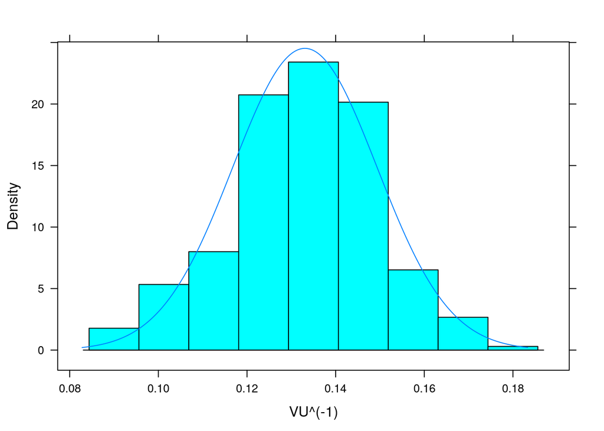

Histograma dos dados transformados.

```r
m <- mean(dados$VU^(-1))
s <- sd(dados$VU^(-1))
histogram(~VU^(-1), dados)
plotDist("norm", mean = m, sd = s, add = TRUE)
```

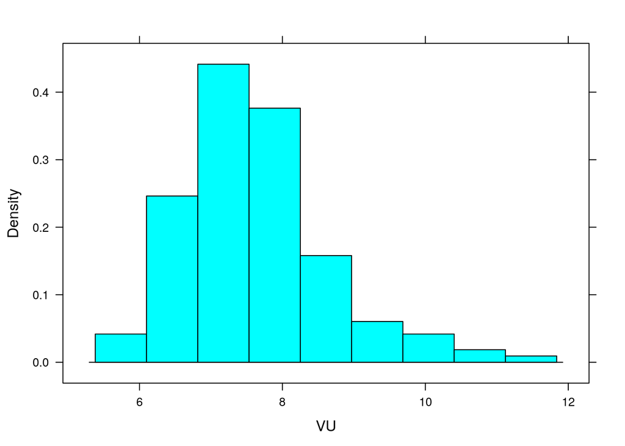

```r
histogram(~VU, dados)
```

Primeiro ajustamos um modelo linear:

```r
linFit <- lm(VU~Area, dados)
summary(linFit)
```

```
##
## Call:
## lm(formula = VU ~ Area, data = dados)
##
## Residuals:
##     Min      1Q  Median      3Q     Max
## -1.9492 -0.6689 -0.0610  0.4189  3.4340
##
## Coefficients:
##              Estimate Std. Error t value Pr(>|t|)
## (Intercept) 10.007935   0.403075   24.83  < 2e-16 ***
## Area        -0.004966   0.000836   -5.94 7.93e-09 ***
## ---
## Signif. codes:  0 '***' 0.001 '**' 0.01 '*' 0.05 '.' 0.1 ' ' 1
##
## Residual standard error: 0.9528 on 298 degrees of freedom
## Multiple R-squared:  0.1059, Adjusted R-squared:  0.1029
## F-statistic: 35.28 on 1 and 298 DF,  p-value: 7.934e-09
```

Percebem-se os problemas do modelo na Figura @ref(fig:linFit):

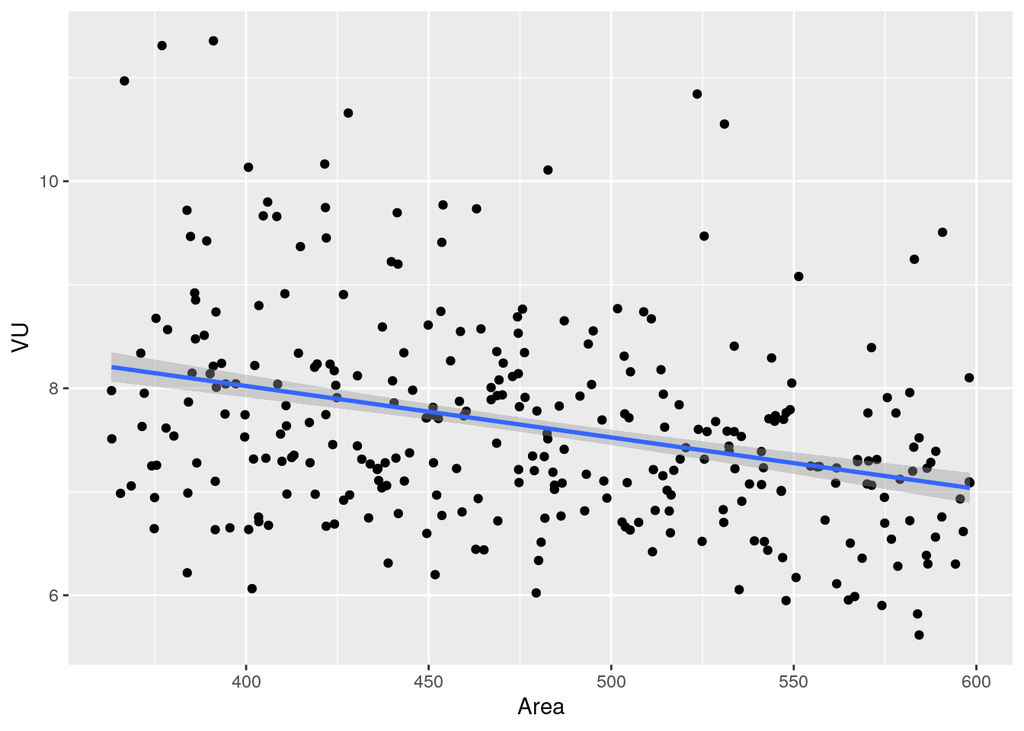

Modelo linear.

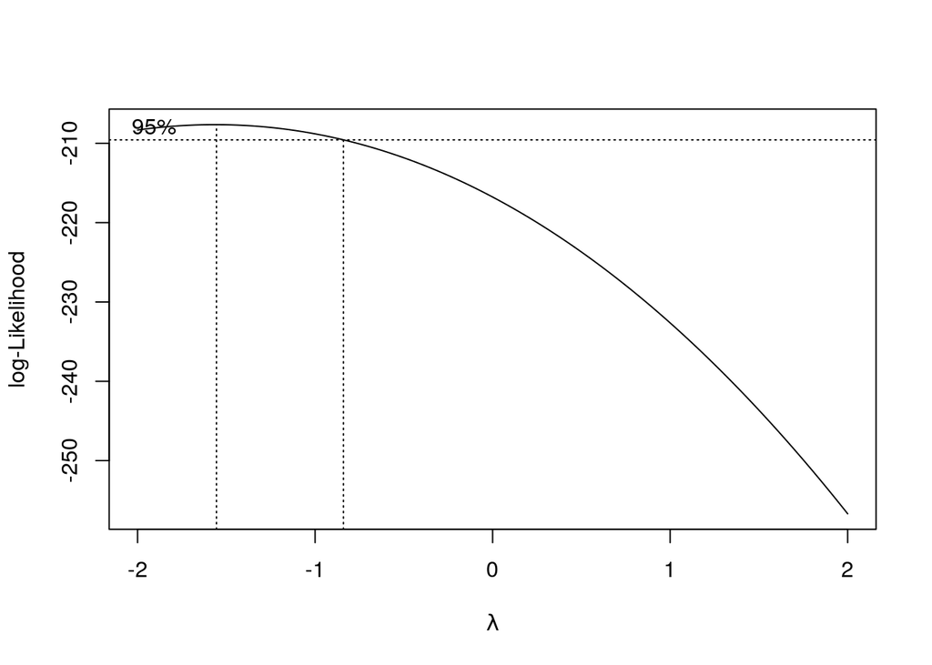

```r
boxcox(linFit)
```

Mais uma vez, fica nítida a não-linearidade pela análise da Figura @ref(fig:linPowerPlot), como no caso da raiz quadrada. Mas é claro que o ajuste está longe do ideal.

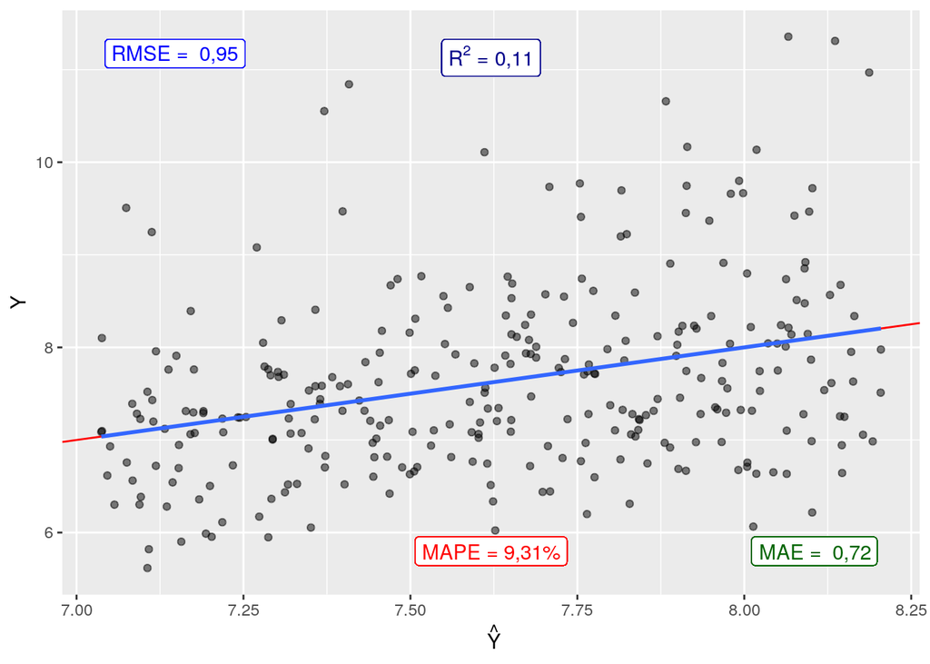

Poder de Predição para o modelo linear.

```r
powerPlot(linFit, axis = "inverted")
```

Ajusta-se então um modelo com a variável transformada.

```r
transFit <- lm(VU^(-1)~Area, dados)
s <- summary(transFit)
s
```

```
##
## Call:
## lm(formula = VU^(-1) ~ Area, data = dados)
##
## Residuals:
##       Min        1Q    Median        3Q       Max
## -0.044648 -0.008939 -0.001051  0.010192  0.038172
##
## Coefficients:
##              Estimate Std. Error t value Pr(>|t|)
## (Intercept) 9.328e-02  6.490e-03  14.374  < 2e-16 ***
## Area        8.328e-05  1.346e-05   6.187 2.02e-09 ***
## ---
## Signif. codes:  0 '***' 0.001 '**' 0.01 '*' 0.05 '.' 0.1 ' ' 1
##
## Residual standard error: 0.01534 on 298 degrees of freedom
## Multiple R-squared:  0.1138, Adjusted R-squared:  0.1109
## F-statistic: 38.28 on 1 and 298 DF,  p-value: 2.018e-09
```

Na Figura @ref(fig:mediana) pode-se ver o Poder de Predição do modelo com a retransformação *naive*, ou seja, com a adoção da mediana.

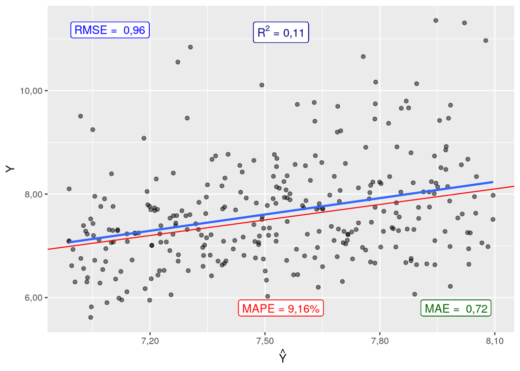

Poder de predição com retransformação

```r
powerPlot(transFit, func = "rec", axis = "inverted")
```

E na Figura @ref(fig:media) pode-se ver o Poder de Predição obtido com a média da distribuição original.

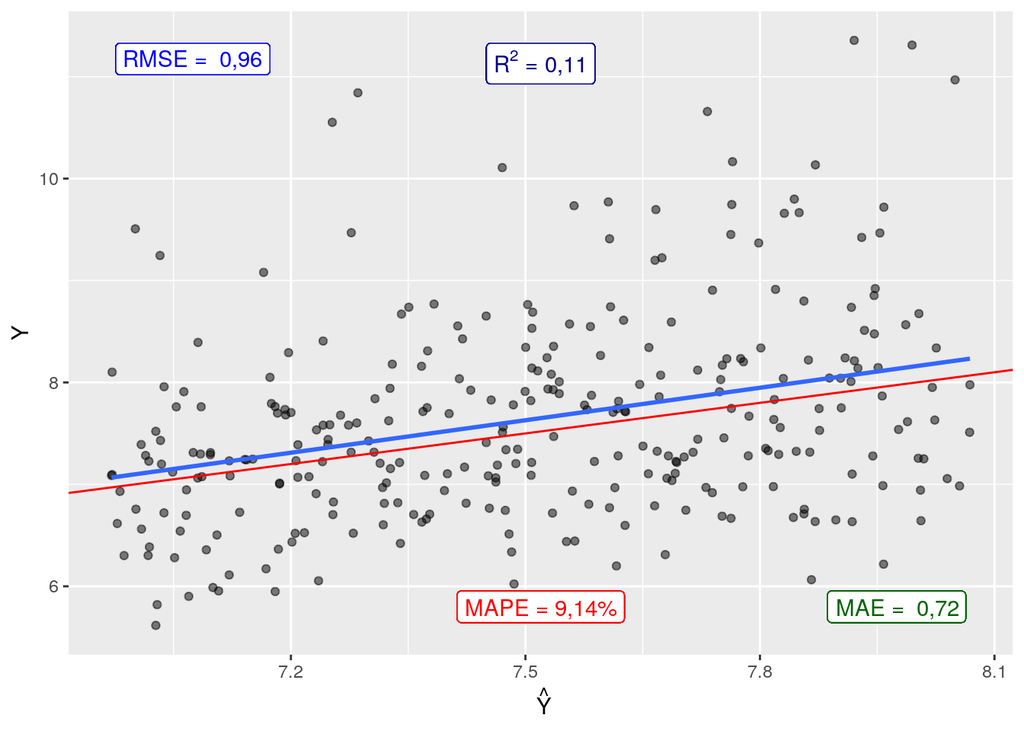

Poder de predição com a média.

```r
yhatMedia <- fitted(transFit)/(fitted(transFit)^2 + s$sigma/300)
powerPlot(dados$VU, yhatMedia, axis = "inverted")
```

É possível perceber que o ajuste dos dados ($R^2$) não aumenta substancialmente. De maneira análoga, aliás, ao que ocorreu com as outras transformações estudadas nos posts anteriores.